# Predicting Tennis Match Outcomes: A Data-Driven Approach to the Game

Team: SNM Analytics

2023-05-01

# Introduction

## Our SMART Question:

What are the most important features that influence the outcome of a tennis match, and how accurately can we predict the winner of a match using a machine learning model based on these features?

This question not only focuses on prediction accuracy but also emphasizes the importance of understanding which factors contribute the most to the outcome. By answering this question, you can gain insights into the game and potentially develop strategies for players or coaches to improve performance.

```r
# Initialize an empty data frame
data <- data.frame()

# Loop through the years and read the corresponding atp_matches files
for (year in 1968:2023) {
  file_path <- paste0("data/atp_matches_", year, ".csv")
  if (file.exists(file_path)) {
    temp_data <- read.csv(file_path)
    data <- rbind(data, temp_data)
  }
}
```

```r
str(data)
```

```
## 'data.frame':    189185 obs. of  49 variables:
##  $ tourney_id        : chr  "1968-2029" "1968-2029" "1968-2029" "1968-2029" ...
##  $ tourney_name      : chr  "Dublin" "Dublin" "Dublin" "Dublin" ...
##  $ surface           : chr  "Grass" "Grass" "Grass" "Grass" ...
##  $ draw_size         : int  32 32 32 32 32 32 32 32 32 32 ...
##  $ tourney_level     : chr  "A" "A" "A" "A" ...
##  $ tourney_date      : int  19680708 19680708 19680708 19680708 19680708 19680708 19680708 19680708 19680708 19680708 ...
##  $ match_num         : int  270 271 272 273 274 275 276 277 278 279 ...
##  $ winner_id         : int  112411 126914 209523 100084 100132 207073 109783 109745 201749 209525 ...
##  $ winner_seed       : chr  NA NA NA NA ...
##  $ winner_entry      : chr  "" "" "" "" ...
##  $ winner_name       : chr  "Douglas Smith" "Louis Pretorius" "Cecil Pedlow" "Tom Okker" ...
##  $ winner_hand       : chr  "U" "R" "U" "R" ...
##  $ winner_ht         : int  NA NA NA 178 NA NA 183 179 NA NA ...
##  $ winner_ioc        : chr  "AUS" "RSA" "IRL" "NED" ...
```

[output cut: 35 more lines]

## Dataset Description

Some of the key features in the dataset are:

1. Player details: player names, ages, heights, etc.
2. Match details: tournament name, surface, round, etc.
3. Player rankings: ATP rankings and ranking points.
4. Match statistics: aces, double faults, first serves in, first serve points won, etc.

# Data Preprocessing/Cleaning & EDA

```r
# Convert tourney_date character type to a Date object
data$tourney_date <- as.Date(as.character(data$tourney_date), "%Y%m%d")
```

```r
# Extract year from tourney_date
data$year <- year(data$tourney_date)
```

```r
# Select the relevant columns (numeric match statistics)
stats_columns <- c("w_ace", "w_df", "w_svpt", "w_1stIn", "w_1stWon", "w_2ndWon", "w_SvGms", "w_bpSaved", "w_bpFaced",
                   "l_ace", "l_df", "l_svpt", "l_1stIn", "l_1stWon", "l_2ndWon", "l_SvGms", "l_bpSaved", "l_bpFaced")
```

```r
# Calculate the percentage of non-null values per year for each numeric variable
non_null_stats <- data %>%
  group_by(year) %>%
  summarize(across(all_of(stats_columns), ~mean(!is.na(.)) * 100, .names = "pct_non_null_{col}"))
```

```r
# Gather the data into a long format for easy plotting
non_null_stats_long <- non_null_stats %>%
  gather(key = "variable", value = "pct_non_null", -year)
```

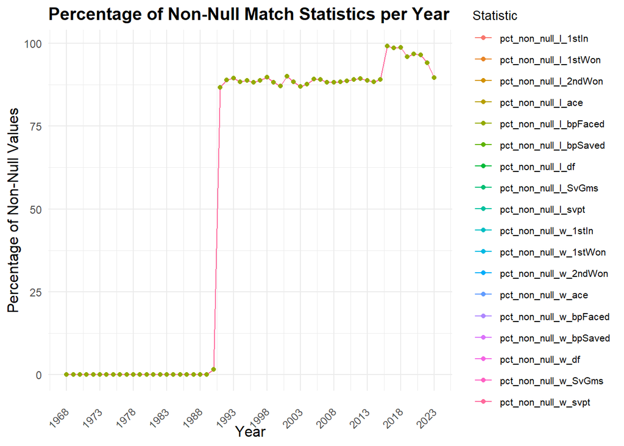

```r
# Plot the percentage of non-null values per year for each numeric variable
ggplot(non_null_stats_long, aes(x = year, y = pct_non_null, color = variable)) +
  geom_line() +
  geom_point() +
  labs(title = "Percentage of Non-Null Match Statistics per Year",
       x = "Year",
       y = "Percentage of Non-Null Values",
       color = "Statistic") +
  theme_minimal() +
  theme(axis.text.x = element_text(angle = 45, vjust = 0.5, hjust = 1),
        plot.title = element_text(size = 14, face = "bold"),
        axis.title.x = element_text(size = 12),
        axis.title.y = element_text(size = 12),
        legend.title = element_text(size = 10),
        legend.text = element_text(size = 8)) +
  scale_x_continuous(breaks = seq(min(non_null_stats_long$year), max(non_null_stats_long$year), by = 5))
```

```r
xkabledply(non_null_stats, digits = 2)
```

Table

| year | pct_non_null_w_ace | pct_non_null_w_df | pct_non_null_w_svpt | pct_non_null_w_1stIn | pct_non_null_w_1stWon | pct_non_null_w_2ndWon | pct_non_null_w_SvGms | pct_non_null_w_bpSaved | pct_non_null_w_bpFaced | pct_non_null_l_ace | pct_non_null_l_df | pct_non_null_l_svpt | pct_non_null_l_1stIn | pct_non_null_l_1stWon | pct_non_null_l_2ndWon | pct_non_null_l_SvGms | pct_non_null_l_bpSaved | pct_non_null_l_bpFaced |
| --- | --- | --- | --- | --- | --- | --- | --- | --- | --- | --- | --- | --- | --- | --- | --- | --- | --- | --- |
| 1968 | 0.00 | 0.0 | 0.0 | 0.0 | 0.0 | 0.0 | 0.0 | 0.0 | 0.0 | 0.0 | 0.00 | 0.0 | 0.0 | 0.0 | 0.0 | 0.0 | 0.0 | 0.0 |
| 1969 | 0.00 | 0.0 | 0.0 | 0.0 | 0.0 | 0.0 | 0.0 | 0.0 | 0.0 | 0.0 | 0.00 | 0.0 | 0.0 | 0.0 | 0.0 | 0.0 | 0.0 | 0.0 |
| 1970 | 0.00 | 0.0 | 0.0 | 0.0 | 0.0 | 0.0 | 0.0 | 0.0 | 0.0 | 0.0 | 0.00 | 0.0 | 0.0 | 0.0 | 0.0 | 0.0 | 0.0 | 0.0 |
| 1971 | 0.00 | 0.0 | 0.0 | 0.0 | 0.0 | 0.0 | 0.0 | 0.0 | 0.0 | 0.0 | 0.00 | 0.0 | 0.0 | 0.0 | 0.0 | 0.0 | 0.0 | 0.0 |
| 1972 | 0.00 | 0.0 | 0.0 | 0.0 | 0.0 | 0.0 | 0.0 | 0.0 | 0.0 | 0.0 | 0.00 | 0.0 | 0.0 | 0.0 | 0.0 | 0.0 | 0.0 | 0.0 |
| 1973 | 0.00 | 0.0 | 0.0 | 0.0 | 0.0 | 0.0 | 0.0 | 0.0 | 0.0 | 0.0 | 0.00 | 0.0 | 0.0 | 0.0 | 0.0 | 0.0 | 0.0 | 0.0 |
| 1974 | 0.00 | 0.0 | 0.0 | 0.0 | 0.0 | 0.0 | 0.0 | 0.0 | 0.0 | 0.0 | 0.00 | 0.0 | 0.0 | 0.0 | 0.0 | 0.0 | 0.0 | 0.0 |
| 1975 | 0.02 | 0.0 | 0.0 | 0.0 | 0.0 | 0.0 | 0.0 | 0.0 | 0.0 | 0.0 | 0.02 | 0.0 | 0.0 | 0.0 | 0.0 | 0.0 | 0.0 | 0.0 |
| 1976 | 0.00 | 0.0 | 0.0 | 0.0 | 0.0 | 0.0 | 0.0 | 0.0 | 0.0 | 0.0 | 0.00 | 0.0 | 0.0 | 0.0 | 0.0 | 0.0 | 0.0 | 0.0 |
| 1977 | 0.00 | 0.0 | 0.0 | 0.0 | 0.0 | 0.0 | 0.0 | 0.0 | 0.0 | 0.0 | 0.00 | 0.0 | 0.0 | 0.0 | 0.0 | 0.0 | 0.0 | 0.0 |
| 1978 | 0.00 | 0.0 | 0.0 | 0.0 | 0.0 | 0.0 | 0.0 | 0.0 | 0.0 | 0.0 | 0.00 | 0.0 | 0.0 | 0.0 | 0.0 | 0.0 | 0.0 | 0.0 |
| 1979 | 0.00 | 0.0 | 0.0 | 0.0 | 0.0 | 0.0 | 0.0 | 0.0 | 0.0 | 0.0 | 0.00 | 0.0 | 0.0 | 0.0 | 0.0 | 0.0 | 0.0 | 0.0 |
| 1980 | 0.00 | 0.0 | 0.0 | 0.0 | 0.0 | 0.0 | 0.0 | 0.0 | 0.0 | 0.0 | 0.00 | 0.0 | 0.0 | 0.0 | 0.0 | 0.0 | 0.0 | 0.0 |
| 1981 | 0.00 | 0.0 | 0.0 | 0.0 | 0.0 | 0.0 | 0.0 | 0.0 | 0.0 | 0.0 | 0.00 | 0.0 | 0.0 | 0.0 | 0.0 | 0.0 | 0.0 | 0.0 |
| 1982 | 0.00 | 0.0 | 0.0 | 0.0 | 0.0 | 0.0 | 0.0 | 0.0 | 0.0 | 0.0 | 0.00 | 0.0 | 0.0 | 0.0 | 0.0 | 0.0 | 0.0 | 0.0 |
| 1983 | 0.00 | 0.0 | 0.0 | 0.0 | 0.0 | 0.0 | 0.0 | 0.0 | 0.0 | 0.0 | 0.00 | 0.0 | 0.0 | 0.0 | 0.0 | 0.0 | 0.0 | 0.0 |
| 1984 | 0.00 | 0.0 | 0.0 | 0.0 | 0.0 | 0.0 | 0.0 | 0.0 | 0.0 | 0.0 | 0.00 | 0.0 | 0.0 | 0.0 | 0.0 | 0.0 | 0.0 | 0.0 |
| 1985 | 0.00 | 0.0 | 0.0 | 0.0 | 0.0 | 0.0 | 0.0 | 0.0 | 0.0 | 0.0 | 0.00 | 0.0 | 0.0 | 0.0 | 0.0 | 0.0 | 0.0 | 0.0 |
| 1986 | 0.00 | 0.0 | 0.0 | 0.0 | 0.0 | 0.0 | 0.0 | 0.0 | 0.0 | 0.0 | 0.00 | 0.0 | 0.0 | 0.0 | 0.0 | 0.0 | 0.0 | 0.0 |
| 1987 | 0.00 | 0.0 | 0.0 | 0.0 | 0.0 | 0.0 | 0.0 | 0.0 | 0.0 | 0.0 | 0.00 | 0.0 | 0.0 | 0.0 | 0.0 | 0.0 | 0.0 | 0.0 |
| 1988 | 0.00 | 0.0 | 0.0 | 0.0 | 0.0 | 0.0 | 0.0 | 0.0 | 0.0 | 0.0 | 0.00 | 0.0 | 0.0 | 0.0 | 0.0 | 0.0 | 0.0 | 0.0 |
| 1989 | 0.00 | 0.0 | 0.0 | 0.0 | 0.0 | 0.0 | 0.0 | 0.0 | 0.0 | 0.0 | 0.00 | 0.0 | 0.0 | 0.0 | 0.0 | 0.0 | 0.0 | 0.0 |
| 1990 | 1.60 | 1.6 | 1.6 | 1.6 | 1.6 | 1.6 | 1.6 | 1.6 | 1.6 | 1.6 | 1.60 | 1.6 | 1.6 | 1.6 | 1.6 | 1.6 | 1.6 | 1.6 |
| 1991 | 86.75 | 86.8 | 86.8 | 86.8 | 86.8 | 86.8 | 86.8 | 86.8 | 86.8 | 86.8 | 86.75 | 86.8 | 86.8 | 86.8 | 86.8 | 86.8 | 86.8 | 86.8 |
| 1992 | 88.90 | 88.9 | 88.9 | 88.9 | 88.9 | 88.9 | 88.9 | 88.9 | 88.9 | 88.9 | 88.90 | 88.9 | 88.9 | 88.9 | 88.9 | 88.9 | 88.9 | 88.9 |
| 1993 | 89.54 | 89.5 | 89.5 | 89.5 | 89.5 | 89.5 | 89.5 | 89.5 | 89.5 | 89.5 | 89.54 | 89.5 | 89.5 | 89.5 | 89.5 | 89.5 | 89.5 | 89.5 |
| 1994 | 88.37 | 88.4 | 88.4 | 88.4 | 88.4 | 88.4 | 88.4 | 88.4 | 88.4 | 88.4 | 88.37 | 88.4 | 88.4 | 88.4 | 88.4 | 88.4 | 88.4 | 88.4 |
| 1995 | 88.82 | 88.8 | 88.8 | 88.8 | 88.8 | 88.8 | 88.8 | 88.8 | 88.8 | 88.8 | 88.82 | 88.8 | 88.8 | 88.8 | 88.8 | 88.8 | 88.8 | 88.8 |
| 1996 | 88.27 | 88.3 | 88.3 | 88.3 | 88.3 | 88.3 | 88.3 | 88.3 | 88.3 | 88.3 | 88.27 | 88.3 | 88.3 | 88.3 | 88.3 | 88.3 | 88.3 | 88.3 |
| 1997 | 88.82 | 88.8 | 88.8 | 88.8 | 88.8 | 88.8 | 88.8 | 88.8 | 88.8 | 88.8 | 88.82 | 88.8 | 88.8 | 88.8 | 88.8 | 88.8 | 88.8 | 88.8 |
| 1998 | 89.81 | 89.8 | 89.8 | 89.8 | 89.8 | 89.8 | 89.8 | 89.8 | 89.8 | 89.8 | 89.81 | 89.8 | 89.8 | 89.8 | 89.8 | 89.8 | 89.8 | 89.8 |
| 1999 | 88.27 | 88.3 | 88.3 | 88.3 | 88.3 | 88.3 | 88.3 | 88.3 | 88.3 | 88.3 | 88.27 | 88.3 | 88.3 | 88.3 | 88.3 | 88.3 | 88.3 | 88.3 |
| 2000 | 87.09 | 87.1 | 87.1 | 87.1 | 87.1 | 87.1 | 87.1 | 87.1 | 87.1 | 87.1 | 87.09 | 87.1 | 87.1 | 87.1 | 87.1 | 87.1 | 87.1 | 87.1 |
| 2001 | 90.00 | 90.0 | 90.0 | 90.0 | 90.0 | 90.0 | 90.0 | 90.0 | 90.0 | 90.0 | 90.00 | 90.0 | 90.0 | 90.0 | 90.0 | 90.0 | 90.0 | 90.0 |
| 2002 | 88.42 | 88.4 | 88.4 | 88.4 | 88.4 | 88.4 | 88.4 | 88.4 | 88.4 | 88.4 | 88.42 | 88.4 | 88.4 | 88.4 | 88.4 | 88.4 | 88.4 | 88.4 |
| 2003 | 86.91 | 86.9 | 86.9 | 86.9 | 86.9 | 86.9 | 86.9 | 86.9 | 86.9 | 86.9 | 86.91 | 86.9 | 86.9 | 86.9 | 86.9 | 86.9 | 86.9 | 86.9 |
| 2004 | 87.59 | 87.6 | 87.6 | 87.6 | 87.6 | 87.6 | 87.6 | 87.6 | 87.6 | 87.6 | 87.59 | 87.6 | 87.6 | 87.6 | 87.6 | 87.6 | 87.6 | 87.6 |
| 2005 | 89.22 | 89.2 | 89.2 | 89.2 | 89.2 | 89.2 | 89.2 | 89.2 | 89.2 | 89.2 | 89.22 | 89.2 | 89.2 | 89.2 | 89.2 | 89.2 | 89.2 | 89.2 |
| 2006 | 89.01 | 89.0 | 89.0 | 89.0 | 89.0 | 89.0 | 89.0 | 89.0 | 89.0 | 89.0 | 89.01 | 89.0 | 89.0 | 89.0 | 89.0 | 89.0 | 89.0 | 89.0 |
| 2007 | 88.25 | 88.2 | 88.2 | 88.2 | 88.2 | 88.2 | 88.2 | 88.2 | 88.2 | 88.2 | 88.25 | 88.2 | 88.2 | 88.2 | 88.2 | 88.2 | 88.2 | 88.2 |
| 2008 | 88.22 | 88.2 | 88.2 | 88.2 | 88.2 | 88.2 | 88.2 | 88.2 | 88.2 | 88.2 | 88.22 | 88.2 | 88.2 | 88.2 | 88.2 | 88.2 | 88.2 | 88.2 |
| 2009 | 88.36 | 88.4 | 88.4 | 88.4 | 88.4 | 88.4 | 88.4 | 88.4 | 88.4 | 88.4 | 88.36 | 88.4 | 88.4 | 88.4 | 88.4 | 88.4 | 88.4 | 88.4 |
| 2010 | 88.65 | 88.7 | 88.7 | 88.7 | 88.7 | 88.7 | 88.7 | 88.7 | 88.7 | 88.7 | 88.65 | 88.7 | 88.7 | 88.7 | 88.7 | 88.7 | 88.7 | 88.7 |
| 2011 | 89.12 | 89.1 | 89.1 | 89.1 | 89.1 | 89.1 | 89.1 | 89.1 | 89.1 | 89.1 | 89.12 | 89.1 | 89.1 | 89.1 | 89.1 | 89.1 | 89.1 | 89.1 |
| 2012 | 89.37 | 89.4 | 89.4 | 89.4 | 89.4 | 89.4 | 89.4 | 89.4 | 89.4 | 89.4 | 89.37 | 89.4 | 89.4 | 89.4 | 89.4 | 89.4 | 89.4 | 89.4 |
| 2013 | 88.72 | 88.7 | 88.7 | 88.7 | 88.7 | 88.7 | 88.7 | 88.7 | 88.7 | 88.7 | 88.72 | 88.7 | 88.7 | 88.7 | 88.7 | 88.7 | 88.7 | 88.7 |
| 2014 | 88.42 | 88.4 | 88.4 | 88.4 | 88.4 | 88.4 | 88.4 | 88.4 | 88.4 | 88.4 | 88.42 | 88.4 | 88.4 | 88.4 | 88.4 | 88.4 | 88.4 | 88.4 |
| 2015 | 89.02 | 89.0 | 89.0 | 89.0 | 89.0 | 89.0 | 89.0 | 89.0 | 89.0 | 89.0 | 89.02 | 89.0 | 89.0 | 89.0 | 89.0 | 89.0 | 89.0 | 89.0 |
| 2016 | 99.15 | 99.2 | 99.2 | 99.2 | 99.2 | 99.2 | 99.2 | 99.2 | 99.2 | 99.2 | 99.15 | 99.2 | 99.2 | 99.2 | 99.2 | 99.2 | 99.2 | 99.2 |
| 2017 | 98.59 | 98.6 | 98.6 | 98.6 | 98.6 | 98.6 | 98.6 | 98.6 | 98.6 | 98.6 | 98.59 | 98.6 | 98.6 | 98.6 | 98.6 | 98.6 | 98.6 | 98.6 |
| 2018 | 98.79 | 98.8 | 98.8 | 98.8 | 98.8 | 98.8 | 98.8 | 98.8 | 98.8 | 98.8 | 98.79 | 98.8 | 98.8 | 98.8 | 98.8 | 98.8 | 98.8 | 98.8 |
| 2019 | 95.92 | 95.9 | 95.9 | 95.9 | 95.9 | 95.9 | 95.9 | 95.9 | 95.9 | 95.9 | 95.92 | 95.9 | 95.9 | 95.9 | 95.9 | 95.9 | 95.9 | 95.9 |
| 2020 | 96.79 | 96.8 | 96.8 | 96.8 | 96.8 | 96.8 | 96.8 | 96.8 | 96.8 | 96.8 | 96.79 | 96.8 | 96.8 | 96.8 | 96.8 | 96.8 | 96.8 | 96.8 |
| 2021 | 96.45 | 96.5 | 96.5 | 96.5 | 96.5 | 96.5 | 96.5 | 96.5 | 96.5 | 96.5 | 96.45 | 96.5 | 96.5 | 96.5 | 96.5 | 96.5 | 96.5 | 96.5 |
| 2022 | 94.10 | 94.1 | 94.1 | 94.1 | 94.1 | 94.1 | 94.1 | 94.1 | 94.1 | 94.1 | 94.10 | 94.1 | 94.1 | 94.1 | 94.1 | 94.1 | 94.1 | 94.1 |
| 2023 | 89.64 | 89.6 | 89.6 | 89.6 | 89.6 | 89.6 | 89.6 | 89.6 | 89.6 | 89.6 | 89.64 | 89.6 | 89.6 | 89.6 | 89.6 | 89.6 | 89.6 | 89.6 |

Since more extensive match level statistics are only available from the year 1991, we concentrate on the ATP match level files from 1991 to 2023.

```r
#Filtering out 1968-1990 data
data <- data %>% filter(year >= 1991)
```

```r
# Sanity check
str(data)
```

```
## 'data.frame':    103245 obs. of  50 variables:
##  $ tourney_id        : chr  "1991-301" "1991-301" "1991-301" "1991-301" ...
##  $ tourney_name      : chr  "Auckland" "Auckland" "Auckland" "Auckland" ...
##  $ surface           : chr  "Hard" "Hard" "Hard" "Hard" ...
##  $ draw_size         : int  32 32 32 32 32 32 32 32 32 32 ...
##  $ tourney_level     : chr  "A" "A" "A" "A" ...
##  $ tourney_date      : Date, format: "1991-01-07" "1991-01-07" ...
##  $ match_num         : int  1 2 3 4 5 6 7 8 9 10 ...
##  $ winner_id         : int  101142 101613 101179 101117 101901 101377 101409 100954 101481 101767 ...
##  $ winner_seed       : chr  "1" NA NA NA ...
##  $ winner_entry      : chr  "" "Q" "" "" ...
##  $ winner_name       : chr  "Emilio Sanchez" "Malivai Washington" "Jean Philippe Fleurian" "Eric Jelen" ...
##  $ winner_hand       : chr  "R" "R" "R" "R" ...
##  $ winner_ht         : int  180 180 185 180 185 180 170 183 188 188 ...
##  $ winner_ioc        : chr  "ESP" "USA" "FRA" "GER" ...
```

[output cut: 36 more lines]

```r
# Analyze missing values in the dataset
missing_values <- data %>%
  gather(variable, value, -tourney_id, -tourney_name, -tourney_date, -match_num, -winner_id, -loser_id) %>%
  mutate(is_missing = is.na(value)) %>%
  group_by(variable) %>%
  summarize(missing_count = sum(is_missing), total_count = n(), missing_percentage = missing_count / total_count * 100)

print(missing_values)
```

```
## # A tibble: 44 × 4
##    variable  missing_count total_count missing_percentage
##    <chr>             <int>       <int>              <dbl>
##  1 best_of               0      103245               0
##  2 draw_size             0      103245               0
##  3 l_1stIn           10195      103245               9.87
##  4 l_1stWon          10195      103245               9.87
##  5 l_2ndWon          10195      103245               9.87
##  6 l_SvGms           10194      103245               9.87
##  7 l_ace             10195      103245               9.87
##  8 l_bpFaced         10195      103245               9.87
##  9 l_bpSaved         10195      103245               9.87
## 10 l_df              10195      103245               9.87
## # … with 34 more rows
```

```r
# Analyze missing values by year
missing_values_by_year <- data %>%
  gather(variable, value, -tourney_id, -tourney_name, -tourney_date, -match_num, -winner_id, -loser_id, -year) %>%
  mutate(is_missing = is.na(value)) %>%
  group_by(year, variable) %>%
  summarize(missing_count = sum(is_missing), total_count = n(), missing_percentage = missing_count / total_count * 100)

print(missing_values_by_year)
```

```
## # A tibble: 1,419 × 5
## # Groups:   year [33]
##     year variable  missing_count total_count missing_percentage
##    <dbl> <chr>             <int>       <int>              <dbl>
##  1  1991 best_of               0        3727                0
##  2  1991 draw_size             0        3727                0
##  3  1991 l_1stIn             494        3727               13.3
##  4  1991 l_1stWon            494        3727               13.3
##  5  1991 l_2ndWon            494        3727               13.3
##  6  1991 l_SvGms             494        3727               13.3
##  7  1991 l_ace               494        3727               13.3
##  8  1991 l_bpFaced           494        3727               13.3
##  9  1991 l_bpSaved           494        3727               13.3
## 10  1991 l_df                494        3727               13.3
## # … with 1,409 more rows
```

## Variables Renaming

Renamed the Variables for better understanding

```r
data <- data %>%
  rename(tournament_id = tourney_id,
         tournament_name = tourney_name,
         tournament_level = tourney_level,
         tournament_date = tourney_date,
         winner_height = winner_ht,
         winner_country = winner_ioc,
         loser_height = loser_ht,
         loser_country = loser_ioc,
         winner_aces = w_ace,
         winner_doublefaults = w_df,
         winner_servepointswon = w_svpt,
         winner_first_serve_in = w_1stIn,
         winner_first_serve_won = w_1stWon,
         winner_second_serve_won = w_2ndWon,
         winner_service_games_held = w_SvGms,
         winner_breakpoints_saved = w_bpSaved,
         winner_breakpoints_faced = w_bpFaced,
         loser_aces = l_ace,
         loser_doublefaults = l_df,
         loser_servepointswon = l_svpt,
         loser_first_serve_in = l_1stIn,
         loser_first_serve_won = l_1stWon,
         loser_second_serve_won = l_2ndWon,
         loser_service_games_held = l_SvGms,
         loser_breakpoints_saved = l_bpSaved,
         loser_breakpoints_faced = l_bpFaced)
```

```r
summary(data)
```

```
##  tournament_id      tournament_name      surface            draw_size
##  Length:103245      Length:103245      Length:103245      Min.   :  2.0
##  Class :character   Class :character   Class :character   1st Qu.: 32.0
##  Mode  :character   Mode  :character   Mode  :character   Median : 32.0
##                                                           Mean   : 53.2
##                                                           3rd Qu.: 64.0
##                                                           Max.   :128.0
##
##  tournament_level   tournament_date        match_num      winner_id
##  Length:103245      Min.   :1991-01-07   Min.   :   1   Min.   :100284
##  Class :character   1st Qu.:1997-09-08   1st Qu.:  10   1st Qu.:102148
##  Mode  :character   Median :2005-06-20   Median :  24   Median :103568
##                     Mean   :2005-12-16   Mean   :  70   Mean   :106213
##                     3rd Qu.:2013-09-30   3rd Qu.:  66   3rd Qu.:104755
##                     Max.   :2023-04-03   Max.   :1701   Max.   :211468
##
##  winner_seed        winner_entry       winner_name        winner_hand
##  Length:103245      Length:103245      Length:103245      Length:103245
##  Class :character   Class :character   Class :character   Class :character
##  Mode  :character   Mode  :character   Mode  :character   Mode  :character
##
##
##
##
##  winner_height  winner_country       winner_age      loser_id
##  Min.   :160    Length:103245      Min.   :14.3   Min.   :100282
##  1st Qu.:180    Class :character   1st Qu.:22.9   1st Qu.:102148
##  Median :185    Mode  :character   Median :25.5   Median :103507
##  Mean   :186                       Mean   :25.8   Mean   :106334
##  3rd Qu.:190                       3rd Qu.:28.3   3rd Qu.:104871
##  Max.   :211                       Max.   :42.7   Max.   :212041
##  NA's   :2382                      NA's   :5
##   loser_seed        loser_entry         loser_name         loser_hand
##  Length:103245      Length:103245      Length:103245      Length:103245
##  Class :character   Class :character   Class :character   Class :character
##  Mode  :character   Mode  :character   Mode  :character   Mode  :character
##
##
##
##
```

[output cut: 57 more lines]

```
##  Min.   :-6              Min.   : 0              Min.   :   1
##  1st Qu.: 2              1st Qu.: 6              1st Qu.:  18
##  Median : 4              Median : 8              Median :  46
##  Mean   : 5              Mean   : 9              Mean   :  81
##  3rd Qu.: 7              3rd Qu.:11              3rd Qu.:  89
##  Max.   :28              Max.   :38              Max.   :2101
##  NA's   :10195           NA's   :10195           NA's   :1187
##  winner_rank_points   loser_rank   loser_rank_points      year
##  Min.   :    1      Min.   :   1   Min.   :    1     Min.   :1991
##  1st Qu.:  527      1st Qu.:  37   1st Qu.:  393     1st Qu.:1997
##  Median :  879      Median :  71   Median :  655     Median :2005
##  Mean   : 1424      Mean   : 119   Mean   :  893     Mean   :2006
##  3rd Qu.: 1592      3rd Qu.: 119   3rd Qu.: 1039     3rd Qu.:2013
##  Max.   :16950      Max.   :2159   Max.   :16950     Max.   :2023
##  NA's   :2113       NA's   :2532   NA's   :3453
```

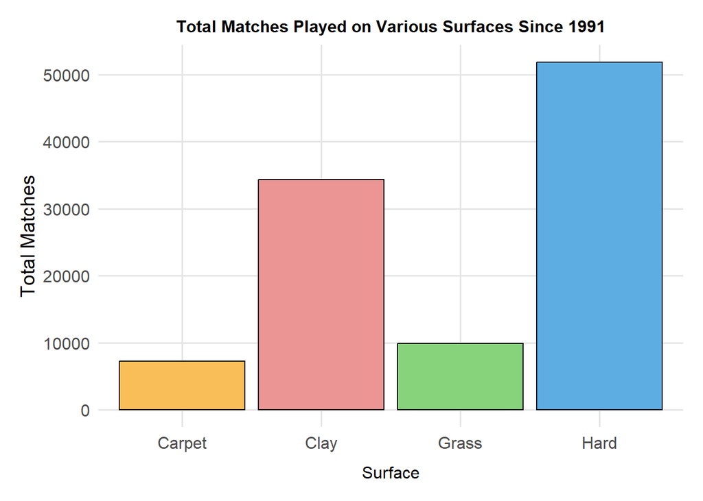

```r
# Define a custom color palette for the surfaces
surface_colors <- c("Clay" = "#EB9694",
                    "Carpet" = "#FABE58",
                    "Grass" = "#87D37C",
                    "Hard" = "#5DADE2")

# Create the bar chart with custom colors and adjusted font sizes
ggplot(data, aes(x = surface, fill = surface)) +
  geom_bar(color = "black") +
  scale_fill_manual(values = surface_colors) +
  labs(title = "Total Matches Played on Various Surfaces Since 1991",
       x = "Surface",
       y = "Total Matches") +
  theme_minimal(base_size = 14) +
  theme(legend.position = "none",
        axis.title.x = element_text(margin = margin(t = 10), size = 12),
        axis.text = element_text(size = 12),
        panel.grid.major = element_line(colour = "gray90"),
        panel.grid.minor = element_blank(),
        panel.border = element_blank(),
        plot.title = element_text(size = 12, face = "bold", hjust = 0.5),
        plot.subtitle = element_text(size = 18, hjust = 0.5, color = "gray40"),
        plot.caption = element_text(size = 14, hjust = 0, color = "gray40"),
        plot.margin = unit(c(0.5, 0.5, 0.5, 0.5), "cm"))
```

Most of the matches played are on hard courts!

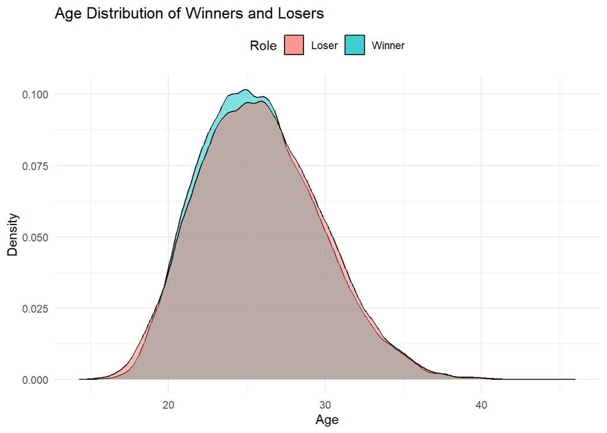

```r
# Filter out rows with missing winner_age and loser_age values
filtered_data <- data %>%
  filter(!is.na(winner_age) & !is.na(loser_age))

# Create a density plot for winner_age and loser_age
ggplot() +
  geom_density(data = filtered_data, aes(x = winner_age, fill = "Winner"), alpha = 0.5) +
  geom_density(data = filtered_data, aes(x = loser_age, fill = "Loser"), alpha = 0.5) +
  labs(x = "Age", y = "Density", title = "Age Distribution of Winners and Losers", fill = "Role") +
  theme_minimal() +
  theme(legend.position = "top")
```

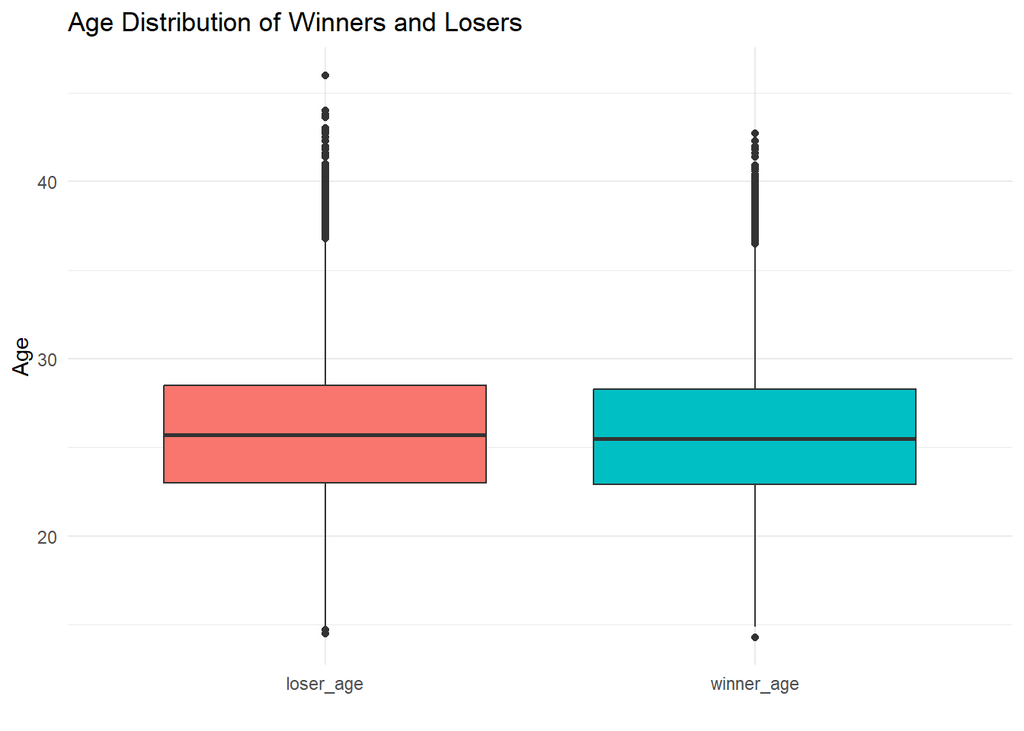

```r
# Create a box plot for winner_age and loser_age
winner_loser_age <- filtered_data %>%
  select(winner_age, loser_age) %>%
  gather(key = "Role", value = "Age", winner_age, loser_age)

ggplot(winner_loser_age, aes(x = Role, y = Age, fill = Role)) +
  geom_boxplot() +
  labs(x = "", y = "Age", title = "Age Distribution of Winners and Losers") +
  theme_minimal() +
  theme(legend.position = "none")
```

Age distribution for “Losers” is wider than “Winners”, although mean value is quite the same: younger and olders players are more likely to loose matches.

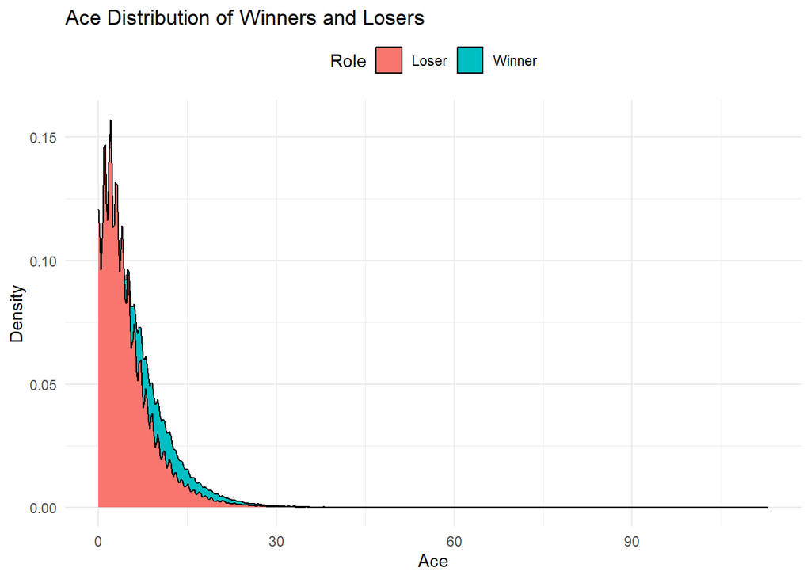

```r
# Filter out rows with missing winner_age and loser_age values
filtered_data <- data %>%
  filter(!is.na(winner_aces) & !is.na(loser_aces))

# Create a density plot for winner_ace and loser_ace
ggplot() +
  geom_density(data = filtered_data, aes(x = winner_aces, fill = "Winner")) +
  geom_density(data = filtered_data, aes(x = loser_aces, fill = "Loser")) +
  labs(x = "Ace", y = "Density", title = "Ace Distribution of Winners and Losers", fill = "Role") +
  theme_minimal() +
  theme(legend.position = "top")
```

Ace Distribution between losers and winners.

```r
# Sanity check
str(data)
```

```
## 'data.frame':    103245 obs. of  50 variables:
##  $ tournament_id            : chr  "1991-301" "1991-301" "1991-301" "1991-301" ...
##  $ tournament_name          : chr  "Auckland" "Auckland" "Auckland" "Auckland" ...
##  $ surface                  : chr  "Hard" "Hard" "Hard" "Hard" ...
##  $ draw_size                : int  32 32 32 32 32 32 32 32 32 32 ...
##  $ tournament_level         : chr  "A" "A" "A" "A" ...
##  $ tournament_date          : Date, format: "1991-01-07" "1991-01-07" ...
##  $ match_num                : int  1 2 3 4 5 6 7 8 9 10 ...
##  $ winner_id                : int  101142 101613 101179 101117 101901 101377 101409 100954 101481 101767 ...
##  $ winner_seed              : chr  "1" NA NA NA ...
##  $ winner_entry             : chr  "" "Q" "" "" ...
##  $ winner_name              : chr  "Emilio Sanchez" "Malivai Washington" "Jean Philippe Fleurian" "Eric Jelen" ...
##  $ winner_hand              : chr  "R" "R" "R" "R" ...
##  $ winner_height            : int  180 180 185 180 185 180 170 183 188 188 ...
##  $ winner_country           : chr  "ESP" "USA" "FRA" "GER" ...
```

[output cut: 36 more lines]

```r
filtered_data <- data %>%
  mutate(winner_first_serve_pct = winner_first_serve_won / winner_first_serve_in,
         winner_second_serve_pct = winner_second_serve_won / (winner_servepointswon - winner_first_serve_in),
         loser_first_serve_pct = loser_first_serve_won / loser_first_serve_in,
         loser_second_serve_pct = loser_second_serve_won / (loser_servepointswon - loser_first_serve_in))
```

```r
xkabledplyhead(filtered_data)
```

Head

| tournament_id | tournament_name | surface | draw_size | tournament_level | tournament_date | match_num | winner_id | winner_seed | winner_entry | winner_name | winner_hand | winner_height | winner_country | winner_age | loser_id | loser_seed | loser_entry | loser_name | loser_hand | loser_height | loser_country | loser_age | score | best_of | round | minutes | winner_aces | winner_doublefaults | winner_servepointswon | … |
| --- | --- | --- | --- | --- | --- | --- | --- | --- | --- | --- | --- | --- | --- | --- | --- | --- | --- | --- | --- | --- | --- | --- | --- | --- | --- | --- | --- | --- | --- | --- |
| 1991-301 | Auckland | Hard | 32 | A | 1991-01-07 | 1 | 101142 | 1 |  | Emilio Sanchez | R | 180 | ESP | 25.6 | 101746 | NA |  | Renzo Furlan | R | 175 | ITA | 20.6 | 6-4 6-1 | 3 | R32 | 63 | 1 | 0 | 53 | … |
| 1991-301 | Auckland | Hard | 32 | A | 1991-01-07 | 2 | 101613 | NA | Q | Malivai Washington | R | 180 | USA | 21.5 | 100587 | NA | WC | Steve Guy | R | 188 | NZL | 31.8 | 6-3 6-2 | 3 | R32 | 72 | 5 | 1 | 56 | … |
| 1991-301 | Auckland | Hard | 32 | A | 1991-01-07 | 3 | 101179 | NA |  | Jean Philippe Fleurian | R | 185 | FRA | 25.3 | 101601 | NA | WC | Brett Steven | R | 185 | NZL | 21.6 | 2-6 6-1 6-2 | 3 | R32 | 101 | 2 | 4 | 80 | … |
| 1991-301 | Auckland | Hard | 32 | A | 1991-01-07 | 4 | 101117 | NA |  | Eric Jelen | R | 180 | GER | 25.8 | 101332 | 8 |  | Gilad Bloom | L | 173 | ISR | 23.8 | 6-3 1-6 6-4 | 3 | R32 | 108 | 0 | 1 | 82 | … |
| 1991-301 | Auckland | Hard | 32 | A | 1991-01-07 | 5 | 101901 | NA | Q | Chuck Adams | R | 185 | USA | 19.7 | 101735 | 3 |  | Richard Fromberg | R | 196 | AUS | 20.6 | 6-3 6-4 | 3 | R32 | 65 | 4 | 4 | 65 | … |

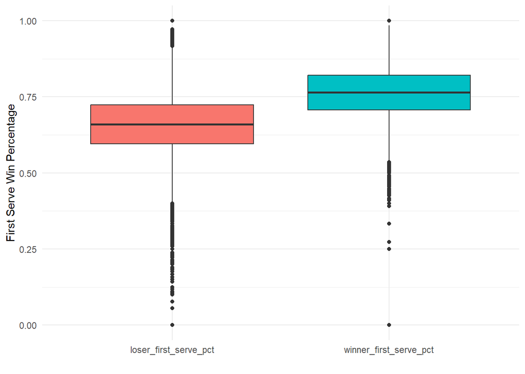

```r
# Prepare the data
winner_loser_data <- filtered_data %>%
  select(winner_first_serve_pct, loser_first_serve_pct) %>%
  gather(key = "Role", value = "First Serve Win Percentage", winner_first_serve_pct, loser_first_serve_pct)

# Create the box plot
box_plot <- ggplot(winner_loser_data, aes(x = Role, y = `First Serve Win Percentage`, fill = Role)) +
  geom_boxplot() +
  labs(x = "", y = "First Serve Win Percentage") +
  theme_minimal() +
  theme(legend.position = "none")

# Display the box plot
print(box_plot)
```

As expected winner first serve winning percentage is quite higher

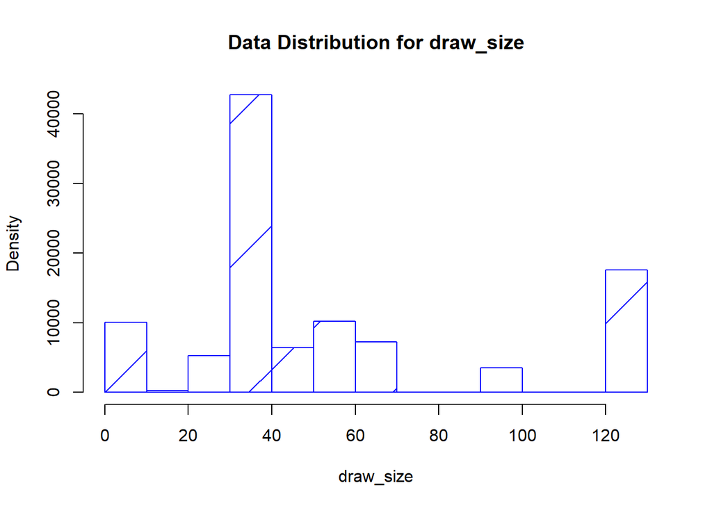

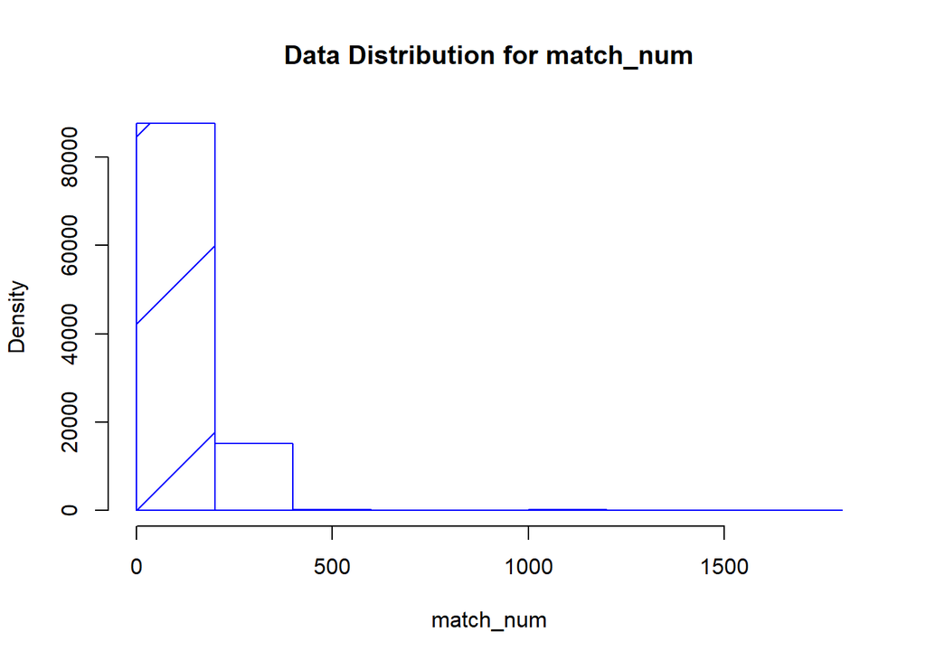

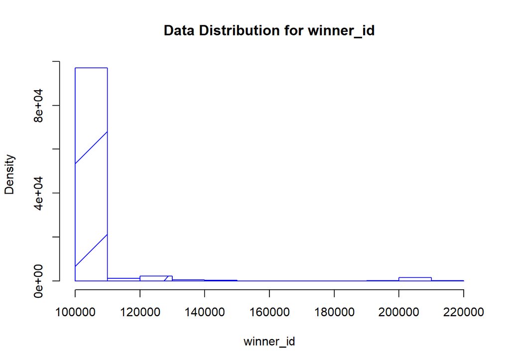

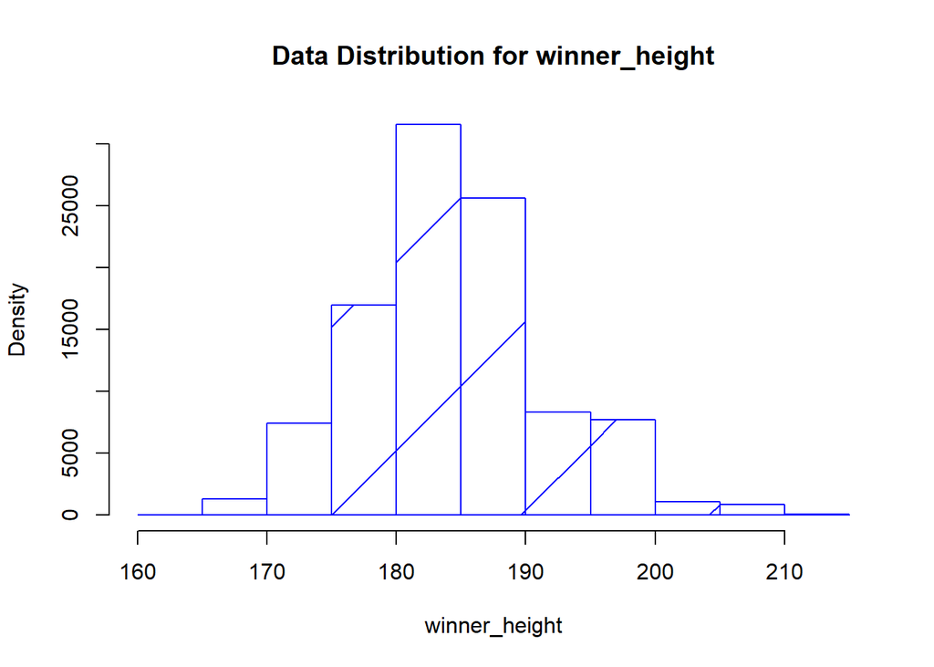

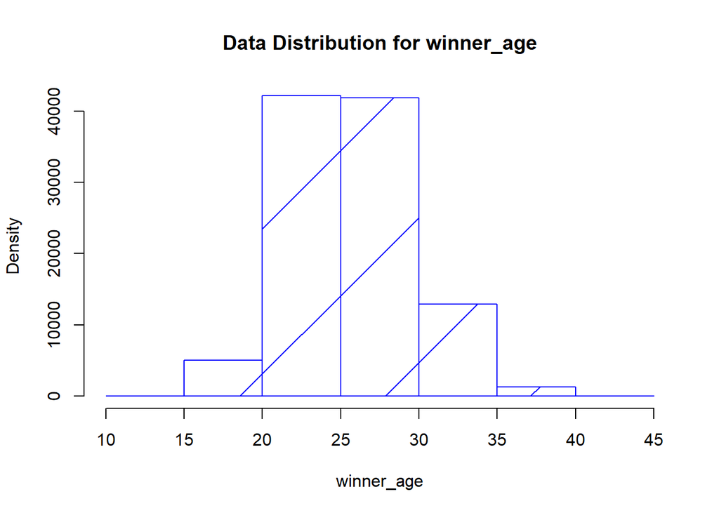

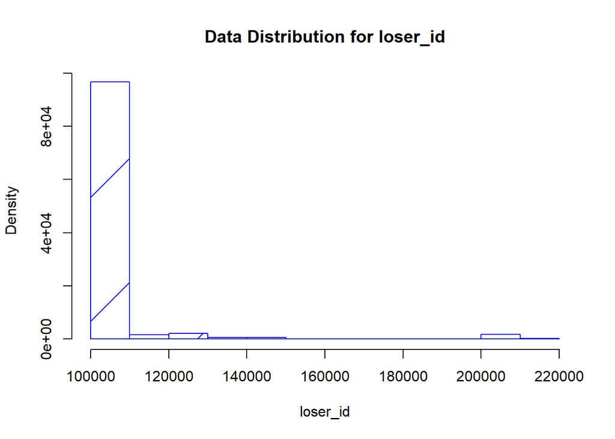

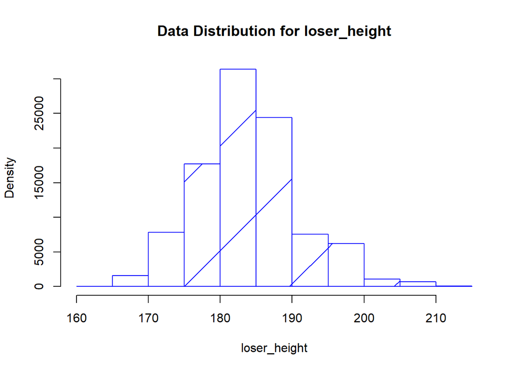

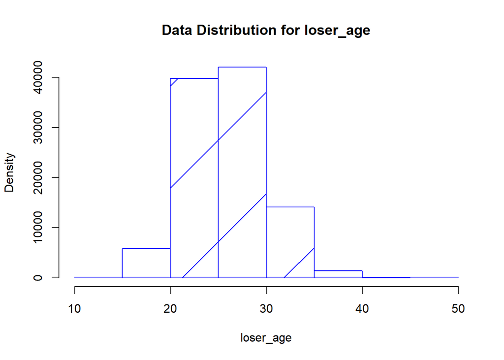

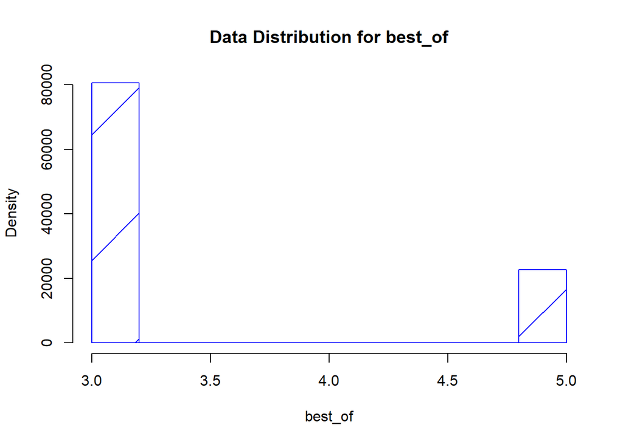

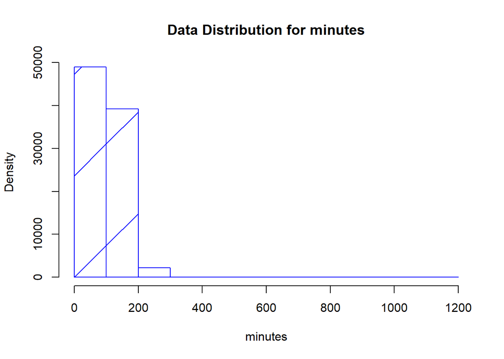

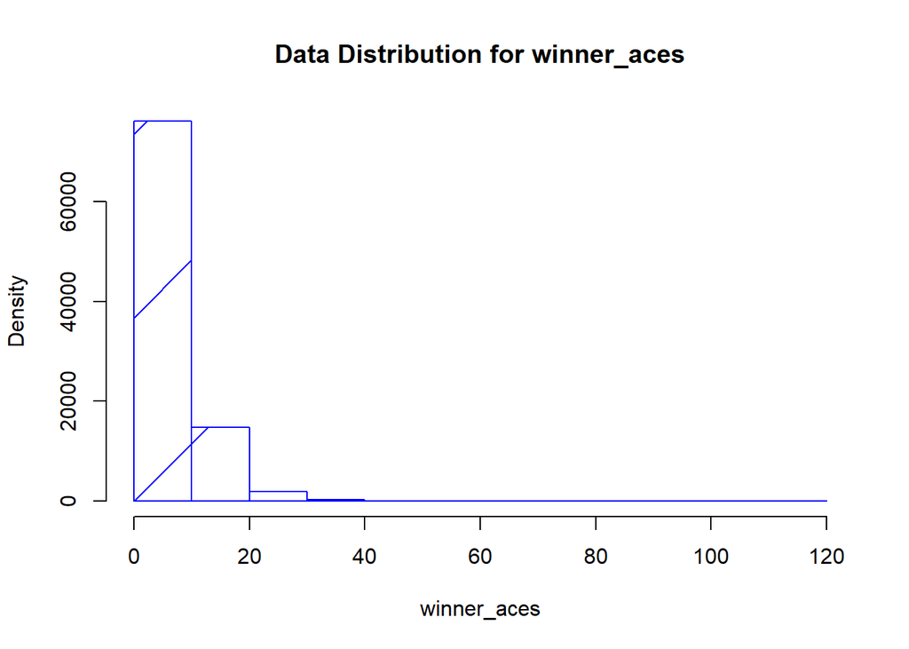

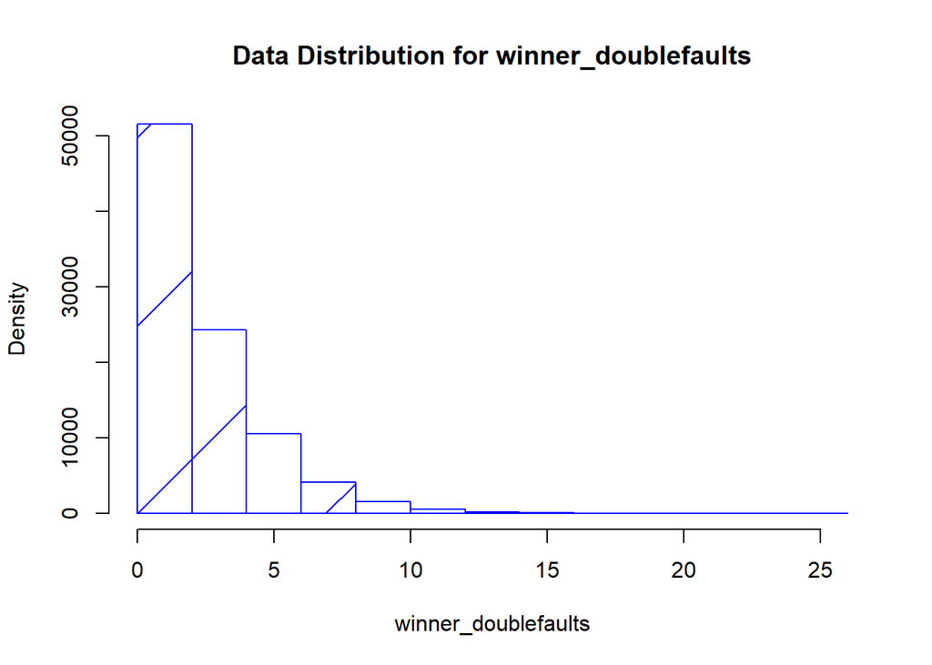

[21 more figures not shown]

```r
#Distribution Graphs for all numeric variables
num_bins <- 10
for (i in names(data)) {
  if (is.numeric(data[[i]])) {
    hist(data[[i]], num_bins, density=TRUE, col='blue', main=paste0("Data Distribution for ", i),
         xlab=i, ylab="Density")
  }
}
```

```r
# suffling the data randomly as it is all sorted year by year
data <- data[sample(1:nrow(data)), ]
```

```r
#Sanity check
str(data)
```

```
## 'data.frame':    103245 obs. of  50 variables:
##  $ tournament_id            : chr  "2000-605" "2005-328" "1994-506" "2000-410" ...
##  $ tournament_name          : chr  "Masters Cup" "Basel" "Buenos Aires" "Monte Carlo Masters" ...
##  $ surface                  : chr  "Hard" "Carpet" "Clay" "Clay" ...
##  $ draw_size                : int  8 32 32 64 128 64 64 128 32 32 ...
##  $ tournament_level         : chr  "F" "A" "A" "M" ...
##  $ tournament_date          : Date, format: "2000-11-27" "2005-10-24" ...
##  $ match_num                : int  5 21 16 43 9 512 63 194 31 295 ...
##  $ winner_id                : int  101736 104571 101475 102104 101793 104386 102796 103893 103428 105062 ...
##  $ winner_seed              : chr  NA NA "2" NA ...
##  $ winner_entry             : chr  "" "Q" "" "Q" ...
##  $ winner_name              : chr  "Andre Agassi" "Marcos Baghdatis" "Carlos Costa" "Christian Ruud" ...
##  $ winner_hand              : chr  "R" "R" "R" "R" ...
##  $ winner_height            : int  180 183 183 188 185 180 188 183 190 183 ...
##  $ winner_country           : chr  "USA" "CYP" "ESP" "NOR" ...
```

[output cut: 36 more lines]

```r
# Determine the number of rows in half the dataset
half_nrow <- nrow(data) %/% 2

# Split the dataset in half
first_half <- data[1:half_nrow, ]
second_half <- data[(half_nrow + 1):nrow(data), ]

# Rename columns for the first half
colnames(first_half)[grep("winner", colnames(first_half))] <- gsub("winner", "player0", colnames(first_half)[grep("winner", colnames(first_half))])
colnames(first_half)[grep("loser", colnames(first_half))] <- gsub("loser", "player1", colnames(first_half)[grep("loser", colnames(first_half))])

# Rename columns for the second half
colnames(second_half)[grep("winner", colnames(second_half))] <- gsub("winner", "player1", colnames(second_half)[grep("winner", colnames(second_half))])
colnames(second_half)[grep("loser", colnames(second_half))] <- gsub("loser", "player0", colnames(second_half)[grep("loser", colnames(second_half))])

# Add 'winner' column to the first half and set it to 0 (player0 is the winner)
first_half$winner <- 0

# Add 'winner' column to the second half and set it to 1 (player1 is the winner)
second_half$winner <- 1

# Combine the two halves
renamed_data <- rbind(first_half, second_half)
```

```r
# Understand the structure of the renamed data
str(renamed_data)
```

```
## 'data.frame':    103245 obs. of  51 variables:
##  $ tournament_id             : chr  "2000-605" "2005-328" "1994-506" "2000-410" ...
##  $ tournament_name           : chr  "Masters Cup" "Basel" "Buenos Aires" "Monte Carlo Masters" ...
##  $ surface                   : chr  "Hard" "Carpet" "Clay" "Clay" ...
##  $ draw_size                 : int  8 32 32 64 128 64 64 128 32 32 ...
##  $ tournament_level          : chr  "F" "A" "A" "M" ...
##  $ tournament_date           : Date, format: "2000-11-27" "2005-10-24" ...
##  $ match_num                 : int  5 21 16 43 9 512 63 194 31 295 ...
##  $ player0_id                : int  101736 104571 101475 102104 101793 104386 102796 103893 103428 105062 ...
##  $ player0_seed              : chr  NA NA "2" NA ...
##  $ player0_entry             : chr  "" "Q" "" "Q" ...
##  $ player0_name              : chr  "Andre Agassi" "Marcos Baghdatis" "Carlos Costa" "Christian Ruud" ...
##  $ player0_hand              : chr  "R" "R" "R" "R" ...
##  $ player0_height            : int  180 183 183 188 185 180 188 183 190 183 ...
##  $ player0_country           : chr  "USA" "CYP" "ESP" "NOR" ...
```

[output cut: 37 more lines]

```r
# Outputing all the randomly shuffled data renamed to a file
# write.csv(renamed_data, "tennis_data.csv", row.names = FALSE)
```

```r
final_data <- read_csv("tennis_data.csv", show_col_types = FALSE)
```

# Feature Engineering and Selection

```r
# selects only the numeric columns from the final_data
numeric_vars <- final_data[, sapply(final_data, is.numeric)]

# computes the correlation matrix for the numeric variables
correlation_matrix <- cor(numeric_vars, use = "complete.obs")

png("heatmap_full.png", width = 800, height = 800)
corrplot(correlation_matrix, method = "color", type = "upper", order = "hclust", tl.col = "black", tl.srt = 45)
dev.off()
```

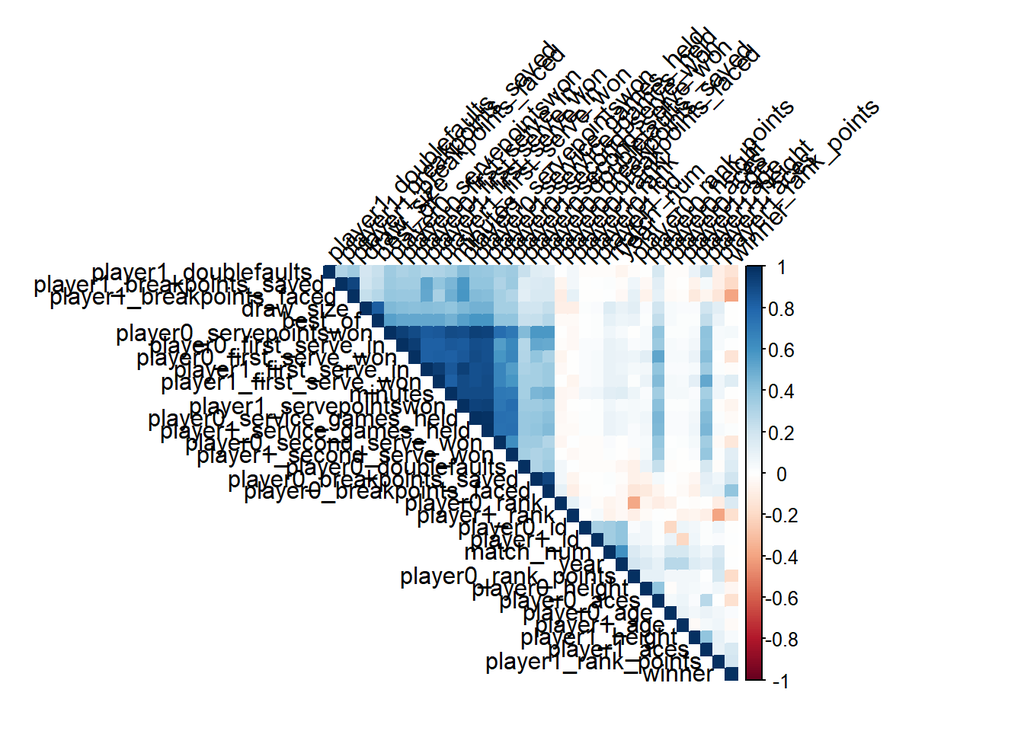

```r
corrplot(correlation_matrix, method = "color", type = "upper", order = "hclust", tl.col = "black", tl.srt = 45)
```

```r
# Keeping threshold as 0.7 for multicolinearity check
threshold <- 0.7
```

```r
correlation_matrix_no_diag <- correlation_matrix
diag(correlation_matrix_no_diag) <- 0
```

```r
highly_correlated_pairs <- which(abs(correlation_matrix_no_diag) > threshold, arr.ind = TRUE)
highly_correlated_pairs
```

```
##                            row col
## best_of                      9   1
## draw_size                    1   9
## player0_servepointswon      13  10
## player0_first_serve_in      14  10
## player0_first_serve_won     15  10
## player0_second_serve_won    16  10
## player0_service_games_held  17  10
## player1_servepointswon      22  10
## player1_first_serve_in      23  10
## player1_first_serve_won     24  10
## player1_second_serve_won    25  10
## player1_service_games_held  26  10
## minutes                     10  13
## player0_first_serve_in      14  13
## player0_first_serve_won     15  13
## player0_second_serve_won    16  13
## player0_service_games_held  17  13
## player1_servepointswon      22  13
## player1_first_serve_in      23  13
## player1_first_serve_won     24  13
## player1_second_serve_won    25  13
## player1_service_games_held  26  13
## minutes                     10  14
## player0_servepointswon      13  14
## player0_first_serve_won     15  14
## player0_service_games_held  17  14
## player1_servepointswon      22  14
## player1_first_serve_in      23  14
## player1_first_serve_won     24  14
## player1_service_games_held  26  14
## minutes                     10  15
## player0_servepointswon      13  15
## player0_first_serve_in      14  15
## player0_service_games_held  17  15
## player1_servepointswon      22  15
## player1_first_serve_in      23  15
## player1_first_serve_won     24  15
## player1_service_games_held  26  15
## minutes                     10  16
```

[output cut: 44 more lines]

```
## player0_service_games_held  17  25
## player1_servepointswon      22  25
## player1_service_games_held  26  25
## minutes                     10  26
## player0_servepointswon      13  26
## player0_first_serve_in      14  26
## player0_first_serve_won     15  26
## player0_second_serve_won    16  26
## player0_service_games_held  17  26
## player1_servepointswon      22  26
## player1_first_serve_in      23  26
## player1_first_serve_won     24  26
## player1_second_serve_won    25  26
## player1_breakpoints_faced   28  27
## player1_breakpoints_saved   27  28
```

```r
highly_correlated_vars <- unique(rownames(highly_correlated_pairs))
highly_correlated_vars
```

```
##  [1] "best_of"                    "draw_size"
##  [3] "player0_servepointswon"     "player0_first_serve_in"
##  [5] "player0_first_serve_won"    "player0_second_serve_won"
##  [7] "player0_service_games_held" "player1_servepointswon"
##  [9] "player1_first_serve_in"     "player1_first_serve_won"
## [11] "player1_second_serve_won"   "player1_service_games_held"
## [13] "minutes"                    "player0_breakpoints_faced"
## [15] "player0_breakpoints_saved"  "player1_breakpoints_faced"
## [17] "player1_breakpoints_saved"
```

we can remove some of the multicollinear variables like draw size and for other we can combine and create new variables to handle multicolinearity

```r
# Removing fields that are not required for the analysis
tennis_data_clean <- final_data %>%
  select(-tournament_id, -tournament_name, -tournament_date, -year, -player0_seed, -player1_seed, -player0_id, -player1_id, -player0_name, -player1_name, -match_num, -score, -round, -draw_size, -player1_country, -player0_country, -player0_entry, -player1_entry, -minutes)
```

```r
ncol(tennis_data_clean)
```

```
## [1] 32
```

```r
# Serve percentage difference
tennis_data_clean$first_serve_pct_diff <- (tennis_data_clean$player0_first_serve_won / tennis_data_clean$player0_first_serve_in) - (tennis_data_clean$player1_first_serve_won / tennis_data_clean$player1_first_serve_in)

# Break points percentage difference
tennis_data_clean$breakpoint_save_pct_diff <- with(tennis_data_clean,
    ifelse(player0_breakpoints_faced == 0, 0, player0_breakpoints_saved / player0_breakpoints_faced) -
    ifelse(player1_breakpoints_faced == 0, 0, player1_breakpoints_saved / player1_breakpoints_faced)
)

# Calculate the ratios of service points won to service games held for both players
tennis_data_clean$player0_serve_points_won_to_games_held_ratio <- ifelse(tennis_data_clean$player0_service_games_held == 0, NA, tennis_data_clean$player0_servepointswon / tennis_data_clean$player0_service_games_held)
tennis_data_clean$player1_serve_points_won_to_games_held_ratio <- ifelse(tennis_data_clean$player1_service_games_held == 0, NA, tennis_data_clean$player1_servepointswon / tennis_data_clean$player1_service_games_held)

# Calculate the difference between the two ratios
tennis_data_clean$serve_points_won_to_games_held_diff <- tennis_data_clean$player0_serve_points_won_to_games_held_ratio - tennis_data_clean$player1_serve_points_won_to_games_held_ratio

# Age difference
tennis_data_clean$age_diff <- tennis_data_clean$player0_age - tennis_data_clean$player1_age

# Height difference
tennis_data_clean$height_diff <- tennis_data_clean$player0_height - tennis_data_clean$player1_height

# Rank difference
tennis_data_clean$rank_diff <- tennis_data_clean$player0_rank - tennis_data_clean$player1_rank

# Rank points difference
tennis_data_clean$rank_points_diff <- tennis_data_clean$player0_rank_points - tennis_data_clean$player1_rank_points
```

```r
tennis_data_clean <- tennis_data_clean %>%
  select(-player0_age, -player1_age, -player0_height, -player1_height, -player0_first_serve_won, -player0_first_serve_in, -player1_first_serve_won, -player1_first_serve_in, -player0_second_serve_won, -player1_second_serve_won, -player1_rank, -player0_rank, -player0_rank_points, -player1_rank_points,
  -player0_breakpoints_faced,
  -player0_breakpoints_saved,
  -player1_breakpoints_faced,
  -player1_breakpoints_saved,
  -player0_service_games_held,
  -player1_servepointswon,
  -player1_service_games_held,
  -player0_servepointswon,
  -player1_servepointswon,
  -player1_service_games_held,
  -player0_servepointswon,
  -player0_service_games_held,
  -player1_service_games_held,
  -player0_servepointswon,
  -player0_service_games_held,
  -player1_servepointswon,
  -player0_serve_points_won_to_games_held_ratio,
  -player1_serve_points_won_to_games_held_ratio,
  )
```

Added new features to handle multicolinearity and also to reduce predictor columns

```r
str(tennis_data_clean)
```

```
## tibble [103,245 × 17] (S3: tbl_df/tbl/data.frame)
##  $ surface                            : chr [1:103245] "Hard" "Hard" "Hard" "Clay" ...
##  $ tournament_level                   : chr [1:103245] "A" "A" "M" "A" ...
##  $ player0_hand                       : chr [1:103245] "R" "R" "R" "R" ...
##  $ player1_hand                       : chr [1:103245] "R" "R" "R" "R" ...
##  $ best_of                            : num [1:103245] 3 3 3 3 3 5 3 3 3 3 ...
##  $ player0_aces                       : num [1:103245] 2 1 4 4 4 7 NA 7 9 0 ...
##  $ player0_doublefaults               : num [1:103245] 4 0 2 3 3 4 NA 1 1 1 ...
##  $ player1_aces                       : num [1:103245] 6 4 3 10 0 6 NA 4 4 4 ...
##  $ player1_doublefaults               : num [1:103245] 7 3 3 2 4 2 NA 3 1 5 ...
##  $ winner                             : num [1:103245] 0 0 0 0 0 0 0 0 0 0 ...
##  $ first_serve_pct_diff               : num [1:103245] -0.1204 0.0821 0.1354 -0.1367 0.3095 ...
##  $ breakpoint_save_pct_diff           : num [1:103245] 0.5 0.25 -0.0833 0.0357 0.3333 ...
##  $ serve_points_won_to_games_held_diff: num [1:103245] 2.111 -0.2 -0.806 0.769 0.714 ...
##  $ age_diff                           : num [1:103245] 0.9 0.9 -6.5 4 0.8 ...
##  $ height_diff                        : num [1:103245] -10 -8 23 -15 -10 0 10 13 5 -2 ...
##  $ rank_diff                          : num [1:103245] -40 -180 -5 149 141 -50 -145 -49 50 2 ...
##  $ rank_points_diff                   : num [1:103245] 2605 504 1425 -912 -289 ...
```

```r
numeric_vars <- tennis_data_clean[, sapply(tennis_data_clean, is.numeric)]
```

```r
correlation_matrix <- cor(numeric_vars, use = "complete.obs")
```

```r
correlation_matrix_no_diag <- correlation_matrix
diag(correlation_matrix_no_diag) <- 0
highly_correlated_pairs <- which(abs(correlation_matrix_no_diag) > threshold, arr.ind = TRUE)
highly_correlated_pairs
```

```
##      row col
```

After removing some variables and feature engineering for others no highly correlated variables

```r
png("heatmap.png", width = 800, height = 800)
corrplot(correlation_matrix, method = "color", type = "upper", order = "hclust", tl.col = "black", tl.srt = 45)
dev.off()
```

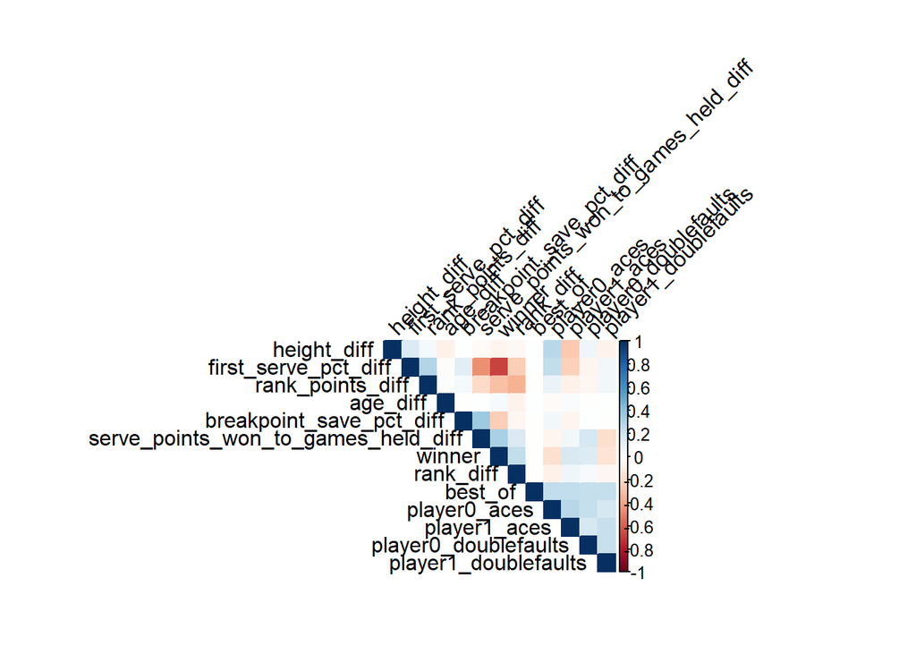

```r
corrplot(correlation_matrix, method = "color", type = "upper", order = "hclust", tl.col = "black", tl.srt = 45)
```

```r
str(tennis_data_clean)
```

```
## tibble [103,245 × 17] (S3: tbl_df/tbl/data.frame)
##  $ surface                            : chr [1:103245] "Hard" "Hard" "Hard" "Clay" ...
##  $ tournament_level                   : chr [1:103245] "A" "A" "M" "A" ...
##  $ player0_hand                       : chr [1:103245] "R" "R" "R" "R" ...
##  $ player1_hand                       : chr [1:103245] "R" "R" "R" "R" ...
##  $ best_of                            : num [1:103245] 3 3 3 3 3 5 3 3 3 3 ...
##  $ player0_aces                       : num [1:103245] 2 1 4 4 4 7 NA 7 9 0 ...
##  $ player0_doublefaults               : num [1:103245] 4 0 2 3 3 4 NA 1 1 1 ...
##  $ player1_aces                       : num [1:103245] 6 4 3 10 0 6 NA 4 4 4 ...
##  $ player1_doublefaults               : num [1:103245] 7 3 3 2 4 2 NA 3 1 5 ...
##  $ winner                             : num [1:103245] 0 0 0 0 0 0 0 0 0 0 ...
##  $ first_serve_pct_diff               : num [1:103245] -0.1204 0.0821 0.1354 -0.1367 0.3095 ...
##  $ breakpoint_save_pct_diff           : num [1:103245] 0.5 0.25 -0.0833 0.0357 0.3333 ...
##  $ serve_points_won_to_games_held_diff: num [1:103245] 2.111 -0.2 -0.806 0.769 0.714 ...
##  $ age_diff                           : num [1:103245] 0.9 0.9 -6.5 4 0.8 ...
##  $ height_diff                        : num [1:103245] -10 -8 23 -15 -10 0 10 13 5 -2 ...
##  $ rank_diff                          : num [1:103245] -40 -180 -5 149 141 -50 -145 -49 50 2 ...
##  $ rank_points_diff                   : num [1:103245] 2605 504 1425 -912 -289 ...
```

```r
# For all numerical variables using mean for missing values
numeric_vars <- sapply(tennis_data_clean, is.numeric)
for (col in colnames(tennis_data_clean)[numeric_vars]) {
  tennis_data_clean[[col]] <- ifelse(is.na(tennis_data_clean[[col]]), mean(tennis_data_clean[[col]], na.rm = TRUE), tennis_data_clean[[col]])
}
```

```r
# Drop rows with missing values in player0_hand or player1_hand
tennis_data_clean <- tennis_data_clean[!is.na(tennis_data_clean$player0_hand) & !is.na(tennis_data_clean$player1_hand), ]
```

```r
# Analyze missing values in the dataset
missing_values <- tennis_data_clean %>%
  gather(variable, value) %>%
  mutate(is_missing = is.na(value)) %>%
  group_by(variable) %>%
  summarize(missing_count = sum(is_missing), total_count = n(), missing_percentage = missing_count / total_count * 100)

print(missing_values)
```

```
## # A tibble: 17 × 4
##    variable                            missing_count total_count missing_perce…¹
##    <chr>                                       <int>       <int>           <dbl>
##  1 age_diff                                        0      103191               0
##  2 best_of                                         0      103191               0
##  3 breakpoint_save_pct_diff                        0      103191               0
##  4 first_serve_pct_diff                            0      103191               0
##  5 height_diff                                     0      103191               0
##  6 player0_aces                                    0      103191               0
##  7 player0_doublefaults                            0      103191               0
##  8 player0_hand                                    0      103191               0
##  9 player1_aces                                    0      103191               0
## 10 player1_doublefaults                            0      103191               0
## 11 player1_hand                                    0      103191               0
## 12 rank_diff                                       0      103191               0
## 13 rank_points_diff                                0      103191               0
## 14 serve_points_won_to_games_held_diff             0      103191               0
## 15 surface                                         0      103191               0
## 16 tournament_level                                0      103191               0
## 17 winner                                          0      103191               0
## # … with abbreviated variable name ¹missing_percentage
```

```r
# Sanity check
str(tennis_data_clean)
```

```
## tibble [103,191 × 17] (S3: tbl_df/tbl/data.frame)
##  $ surface                            : chr [1:103191] "Hard" "Hard" "Hard" "Clay" ...
##  $ tournament_level                   : chr [1:103191] "A" "A" "M" "A" ...
##  $ player0_hand                       : chr [1:103191] "R" "R" "R" "R" ...
##  $ player1_hand                       : chr [1:103191] "R" "R" "R" "R" ...
##  $ best_of                            : num [1:103191] 3 3 3 3 3 5 3 3 3 3 ...
##  $ player0_aces                       : num [1:103191] 2 1 4 4 4 ...
##  $ player0_doublefaults               : num [1:103191] 4 0 2 3 3 ...
##  $ player1_aces                       : num [1:103191] 6 4 3 10 0 ...
##  $ player1_doublefaults               : num [1:103191] 7 3 3 2 4 ...
##  $ winner                             : num [1:103191] 0 0 0 0 0 0 0 0 0 0 ...
##  $ first_serve_pct_diff               : num [1:103191] -0.1204 0.0821 0.1354 -0.1367 0.3095 ...
##  $ breakpoint_save_pct_diff           : num [1:103191] 0.5 0.25 -0.0833 0.0357 0.3333 ...
##  $ serve_points_won_to_games_held_diff: num [1:103191] 2.111 -0.2 -0.806 0.769 0.714 ...
##  $ age_diff                           : num [1:103191] 0.9 0.9 -6.5 4 0.8 ...
##  $ height_diff                        : num [1:103191] -10 -8 23 -15 -10 0 10 13 5 -2 ...
##  $ rank_diff                          : num [1:103191] -40 -180 -5 149 141 -50 -145 -49 50 2 ...
##  $ rank_points_diff                   : num [1:103191] 2605 504 1425 -912 -289 ...
```

```r
# Converting all categorical variables to factors
tennis_data_clean$surface <- as.factor(tennis_data_clean$surface)
tennis_data_clean$tournament_level <- as.factor(tennis_data_clean$tournament_level)
tennis_data_clean$player0_hand <- as.factor(tennis_data_clean$player0_hand)
tennis_data_clean$player1_hand <- as.factor(tennis_data_clean$player1_hand)
```

```r
# sanity check
str(tennis_data_clean)
```

```
## tibble [103,191 × 17] (S3: tbl_df/tbl/data.frame)
##  $ surface                            : Factor w/ 4 levels "Carpet","Clay",..: 4 4 4 2 2 3 4 4 4 4 ...
##  $ tournament_level                   : Factor w/ 5 levels "A","D","F","G",..: 1 1 5 1 1 4 1 1 1 1 ...
##  $ player0_hand                       : Factor w/ 4 levels "A","L","R","U": 3 3 3 3 3 3 3 3 2 3 ...
##  $ player1_hand                       : Factor w/ 4 levels "A","L","R","U": 3 3 3 3 2 3 3 2 3 3 ...
##  $ best_of                            : num [1:103191] 3 3 3 3 3 5 3 3 3 3 ...
##  $ player0_aces                       : num [1:103191] 2 1 4 4 4 ...
##  $ player0_doublefaults               : num [1:103191] 4 0 2 3 3 ...
##  $ player1_aces                       : num [1:103191] 6 4 3 10 0 ...
##  $ player1_doublefaults               : num [1:103191] 7 3 3 2 4 ...
##  $ winner                             : num [1:103191] 0 0 0 0 0 0 0 0 0 0 ...
##  $ first_serve_pct_diff               : num [1:103191] -0.1204 0.0821 0.1354 -0.1367 0.3095 ...
##  $ breakpoint_save_pct_diff           : num [1:103191] 0.5 0.25 -0.0833 0.0357 0.3333 ...
##  $ serve_points_won_to_games_held_diff: num [1:103191] 2.111 -0.2 -0.806 0.769 0.714 ...
##  $ age_diff                           : num [1:103191] 0.9 0.9 -6.5 4 0.8 ...
##  $ height_diff                        : num [1:103191] -10 -8 23 -15 -10 0 10 13 5 -2 ...
##  $ rank_diff                          : num [1:103191] -40 -180 -5 149 141 -50 -145 -49 50 2 ...
##  $ rank_points_diff                   : num [1:103191] 2605 504 1425 -912 -289 ...
```

```r
# spliting the data set into train and test
set.seed(123)
trainIndex <- createDataPartition(tennis_data_clean$winner, p = .7, list = FALSE, times = 1)
train_set <- tennis_data_clean[trainIndex, ]
test_set <- tennis_data_clean[-trainIndex, ]
```

# Modeling

## Logistic Regression

```r
logistic_model <- glm(winner ~., family = binomial(link = "logit"), data = train_set)
```

```r
predictions <- predict(logistic_model, test_set, type = "response")
predicted_classes <- ifelse(predictions > 0.5, 1, 0)
predicted_classes <- factor(ifelse(predictions > 0.5, 1, 0), levels = c(0, 1))
test_set$winner <- factor(test_set$winner, levels = c(0, 1))
cm <- confusionMatrix(predicted_classes, test_set$winner)
```

```r
cm
```

```
## Confusion Matrix and Statistics
##
##           Reference
## Prediction     0     1
##          0 13001  2371
##          1  2394 13191
##
##                Accuracy : 0.846
##                  95% CI : (0.842, 0.85)
##     No Information Rate : 0.503
##     P-Value [Acc > NIR] : <2e-16
##
##                   Kappa : 0.692
##
##  Mcnemar's Test P-Value : 0.75
##
##             Sensitivity : 0.844
##             Specificity : 0.848
##          Pos Pred Value : 0.846
##          Neg Pred Value : 0.846
##              Prevalence : 0.497
##          Detection Rate : 0.420
##    Detection Prevalence : 0.497
##       Balanced Accuracy : 0.846
##
##        'Positive' Class : 0
##
```

```r
cm_df <- as.data.frame(cm$table)
colnames(cm_df) <- c("Prediction", "Reference", "n")
```

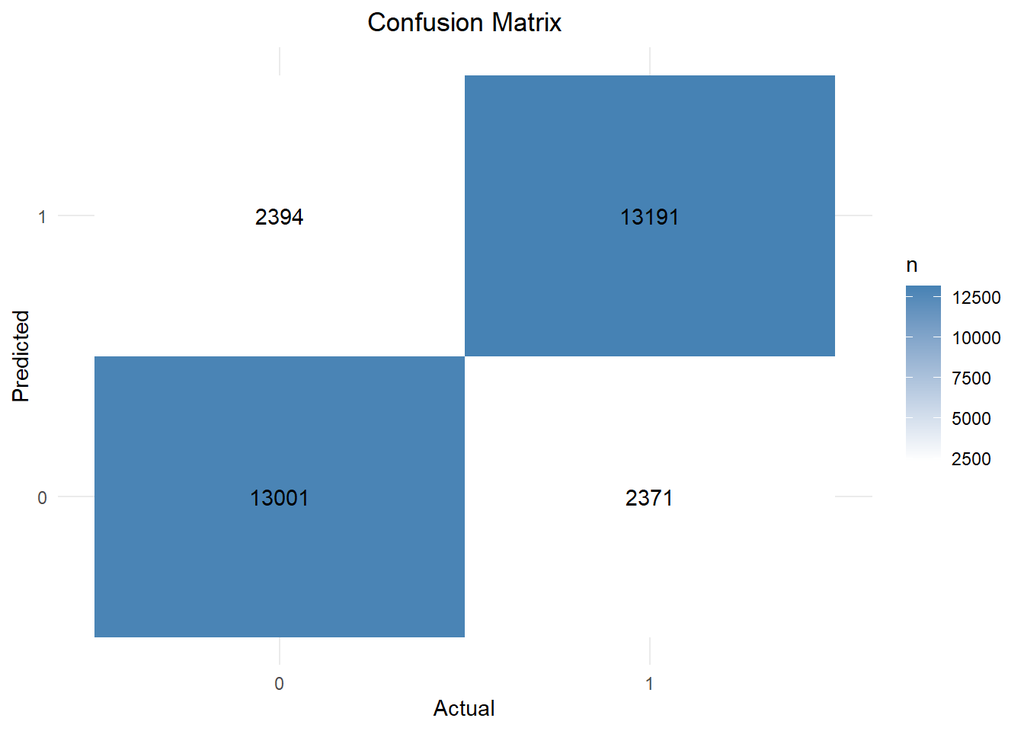

```r
plot_confusion_matrix <- function(cm_df) {
  ggplot(data = cm_df, aes(x = Reference, y = Prediction, fill = n)) +
    geom_tile() +
    geom_text(aes(label = n), color = "black") +
    scale_fill_gradient(low = "white", high = "steelblue") +
    theme_minimal() +
    xlab("Actual") +
    ylab("Predicted") +
    ggtitle("Confusion Matrix") +
    theme(plot.title = element_text(hjust = 0.5))
}

plot_cm <- plot_confusion_matrix(cm_df)
print(plot_cm)
```

```r
accuracy <- cm$overall["Accuracy"]
sensitivity <- cm$byClass["Sensitivity"]
specificity <- cm$byClass["Specificity"]
f1_score <- cm$byClass["F1"]

cat("Accuracy: ", accuracy, "\n")
```

```
## Accuracy:  0.846
```

```r
cat("Sensitivity (Recall): ", sensitivity, "\n")
```

```
## Sensitivity (Recall):  0.844
```

```r
cat("Specificity: ", specificity, "\n")
```

```
## Specificity:  0.848
```

```r
cat("F1-score: ", f1_score, "\n")
```

```
## F1-score:  0.845
```

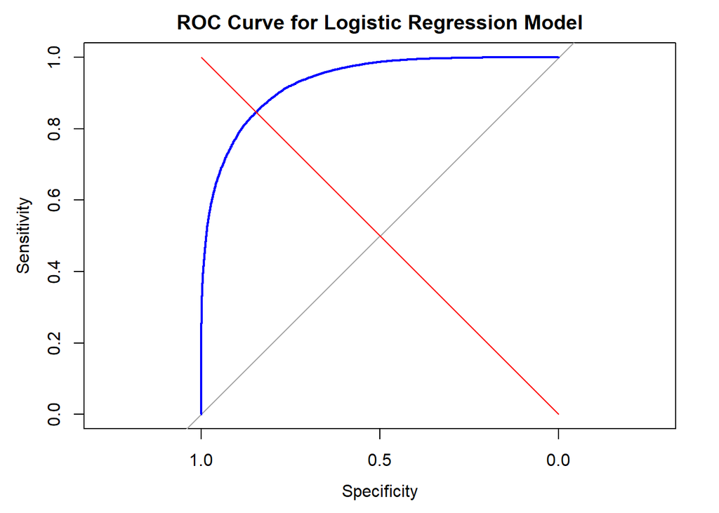

```r
roc_curve <- roc(test_set$winner, predictions)
plot(roc_curve, col = "blue", main = "ROC Curve for Logistic Regression Model")
lines(x = c(0, 1), y = c(0, 1), col = "red")
```

```r
roc_auc <- auc(roc_curve)
```

```r
vif(logistic_model)
```

```
##                                     GVIF Df GVIF^(1/(2*Df))
## surface                             1.22  3            1.03
## tournament_level                    6.07  4            1.25
## player0_hand                        1.16  3            1.03
## player1_hand                        1.17  3            1.03
## best_of                             4.64  1            2.15
## player0_aces                        1.50  1            1.23
## player0_doublefaults                1.27  1            1.13
## player1_aces                        1.48  1            1.22
## player1_doublefaults                1.26  1            1.12
## first_serve_pct_diff                1.42  1            1.19
## breakpoint_save_pct_diff            1.50  1            1.22
## serve_points_won_to_games_held_diff 1.69  1            1.30
## age_diff                            1.02  1            1.01
## height_diff                         1.26  1            1.12
## rank_diff                           1.13  1            1.06
## rank_points_diff                    1.12  1            1.06
```

```r
train_set$winner <- as.factor(train_set$winner)
test_set$winner <- as.factor(test_set$winner)
levels(train_set$winner) <- c("Winner_0", "Winner_1")
levels(test_set$winner) <- c("Winner_0", "Winner_1")
```